# 39_TilakPoudel 2nd Assessment

Tilak Poudel

2025-05-28

# Q.N 6

Create a dataset with following variables: age (20-59) years height (110-190) cm weight (40-90) kg with random 150 cases of each variable with random seed 39

## a

```r
working_directory <- getwd()
print(working_directory)
```

```
## [1] "/home/tilak/projects/tilak/mds1/R-programming/exam/2nd-assessment/39_TilakPoudel"
```

```r
# Change to the desired directory
# setwd("~/projects/tilak/mds1/R-programming/")
set.seed(39)
# Generate the data
data <- data.frame(
  age = sample(20:59, 150, replace = TRUE),
  height = sample(110:190, 150, replace = TRUE),
  weight = sample(40:90, 150, replace = TRUE)
)

print(data)
```

```
##     age height weight
## 1    38    143     67
## 2    27    126     63
## 3    59    142     68
## 4    33    154     87
## 5    43    115     68
## 6    31    185     76
## 7    32    187     62
## 8    37    129     84
## 9    49    175     48
## 10   29    138     67
## 11   33    178     86
## 12   33    139     82
## 13   43    145     45
## 14   49    169     64
```

[output cut: 136 more lines]

# b compute the body mass index variable as : BMI = weight in kg / height in meter squared

```r
data$BMI <- data$weight / (data$height / 100)^2
print(head(data))
```

```
##   age height weight      BMI
## 1  38    143     67 32.76444
## 2  27    126     63 39.68254
## 3  59    142     68 33.72347
## 4  33    154     87 36.68410
## 5  43    115     68 51.41777
## 6  31    185     76 22.20599
```

# c create a body mass index category variable as follows: <18, 18-24, 25-30, 30+ and label them as “underweight”, “normal”, “overweight”, “obese” using dplyr package

```r
library(dplyr)
data <- data %>%
  mutate(BMI_category = case_when(
    BMI < 18 ~ "underweight",
    BMI >= 18 & BMI < 25 ~ "normal",
    BMI >= 25 & BMI < 30 ~ "overweight",
    TRUE ~ "obese"
  ))
print(head(data))
```

```
##   age height weight      BMI BMI_category
## 1  38    143     67 32.76444        obese
## 2  27    126     63 39.68254        obese
## 3  59    142     68 33.72347        obese
## 4  33    154     87 36.68410        obese
## 5  43    115     68 51.41777        obese
## 6  31    185     76 22.20599       normal
```

# show percentage distribution of labelled BMI variable with pie chart using ggplot2 package

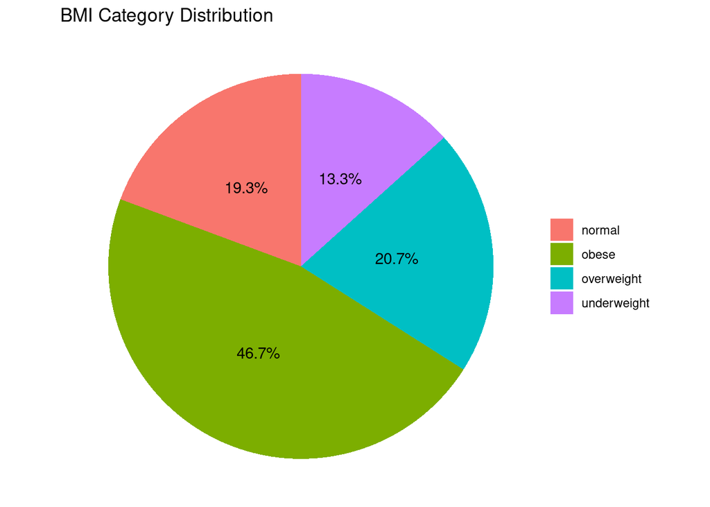

```r
library(ggplot2)
ggplot(data, aes(x = "", fill = BMI_category)) +
  geom_bar(width = 1) +
  coord_polar(theta = "y") +
  labs(title = "BMI Category Distribution") +
  theme_void() +
  theme(legend.title = element_blank()) +
  geom_text(stat = 'count', aes(label = scales::percent(..count../sum(..count..))), position = position_stack(vjust = 0.5))
```

From the pie chart we can see that the distribution of BMI categories is as follows: - Underweight: 13.3% - Normal: 19.3% - Overweight: 20.7% - Obese: 46.7%

# Q.N 7

## Using airquality dataset, do the following:

### a. Perform notmality of “Temp” variable by each category of “Month” variable and interpret

```r
library(dplyr)
data("airquality")
print(head(airquality))
```

```
##   Ozone Solar.R Wind Temp Month Day
## 1    41     190  7.4   67     5   1
## 2    36     118  8.0   72     5   2
## 3    12     149 12.6   74     5   3
## 4    18     313 11.5   62     5   4
## 5    NA      NA 14.3   56     5   5
## 6    28      NA 14.9   66     5   6
```

```r
# see category of Month variable
print(unique(airquality$Month))
```

```
## [1] 5 6 7 8 9
```

```r
shapiro_results <- airquality %>%
  group_by(Month) %>%
  summarise(
    shapiro_p_value = shapiro.test(Temp)$p.value
  )
print(shapiro_results)
```

```
## # A tibble: 5 × 2
##   Month shapiro_p_value
##   <int>           <dbl>
## 1     5           0.135
## 2     6           0.583
## 3     7           0.119
## 4     8           0.369
## 5     9           0.183
```

## Interpretation

The Shapiro-Wilk test results indicate the following p-values for the “Temp” variable by each month: - May: 0.134 - June: 583 - July: 119 - August: 368 - September: 0.183

For all months, Temp appears to follow a normal distribution (`p > 0.05`), so parametric tests (like t-tests or ANOVA) could be appropriate.

# b. Perform test of equality of variance of “Temp” variable by each category of “Month” variable and interpret

```r
library(car)
# Perform Levene's test for equality of variance
levene_results <- leveneTest(Temp ~ factor(Month), data = airquality)
print(levene_results)
```

```
## Levene's Test for Homogeneity of Variance (center = median)
##        Df F value  Pr(>F)
## group   4  2.5849 0.03941 *
##       148
## ---
## Signif. codes:  0 '***' 0.001 '**' 0.01 '*' 0.05 '.' 0.1 ' ' 1
```

## Interpretation

The Levene’s test results indicate the following: - F-value: 2.584 - p-value: 0.0394 This suggests that there is a `significant difference in the variances of the "Temp" variable across different months` (`p < 0.05`). Therefore, we cannot assume equal variances for the “Temp” variable across the months.

# c. Compare temp by month using best statistical test for this data and interpret

Since the data is

Data is approximately normal, but

Variances are not equal, we will use ANOVA compare the means of “Temp” across different months.

```r
# Perform ANOVA to compare "Temp" across different months
anova_results <- aov(Temp ~ factor(Month), data = airquality)
summary_anova <- summary(anova_results)
print(summary_anova)
```

```
##                Df Sum Sq Mean Sq F value Pr(>F)
## factor(Month)   4   7061  1765.3   39.85 <2e-16 ***
## Residuals     148   6557    44.3
## ---
## Signif. codes:  0 '***' 0.001 '**' 0.01 '*' 0.05 '.' 0.1 ' ' 1
```

## Interpretation

F-value = 39.85, and

p-value < 2e-16, which is much less than 0.05.

So we can say, there is a statistically significant difference in mean temperature across the five months (May to September).

# d. Perform post-hoc test to find which month is different from which month

```r
# Perform Tukey's HSD post-hoc test
tukey_results <- TukeyHSD(anova_results)
print(tukey_results)
```

```
##   Tukey multiple comparisons of means
##     95% family-wise confidence level
##
## Fit: aov(formula = Temp ~ factor(Month), data = airquality)
##
## $`factor(Month)`
##            diff          lwr       upr     p adj
## 6-5 13.55161290   8.84386422 18.259362 0.0000000
## 7-5 18.35483871  13.68583759 23.023840 0.0000000
## 8-5 18.41935484  13.75035372 23.088356 0.0000000
## 9-5 11.35161290   6.64386422 16.059362 0.0000000
## 7-6  4.80322581   0.09547713  9.510974 0.0430674
## 8-6  4.86774194   0.15999325  9.575491 0.0388654
## 9-6 -2.20000000  -6.94617992  2.546180 0.7038121
## 8-7  0.06451613  -4.60448499  4.733517 0.9999995
## 9-7 -7.00322581 -11.71097449 -2.295477 0.0006215
## 9-8 -7.06774194 -11.77549062 -2.359993 0.0005376
```

## Interpretation

The Tukey’s HSD post-hoc test results indicate significant differences in mean temperature between several pairs of months. We can summarize the findings as follows: - May has the coolest temps compared to all other months — all comparisons with May show significant positive differences.

- June, July, and August are warmer months, with July and August temperatures being very similar (not significantly different).
- September temps drop compared to July and August (significant negative differences).
- September and June temps are not significantly different.

# Q.N 8

Do the following: a. Create a dataset with 200 random cases, 1 random binary (1 and 0), variable four randon (cateogorical and contnuous) variable with seed of 39

```r
set.seed(39)
data_8 <- data.frame(
  binary_var = sample(0:1, 200, replace = TRUE),
  categorical_var1 = sample(c("A", "B", "C"), 200, replace = TRUE),
  categorical_var2 = sample(c("X", "Y"), 200, replace = TRUE),
  continuous_var1 = rnorm(200, mean = 50, sd = 10),
  continuous_var2 = rnorm(200, mean = 100, sd = 20)
)
print(head(data_8))
```

```
##   binary_var categorical_var1 categorical_var2 continuous_var1 continuous_var2
## 1          0                A                X        37.35157        77.84065
## 2          0                C                X        66.21572       108.19520
## 3          1                A                X        34.17535       112.77027
## 4          1                B                X        31.04624        98.37346
## 5          1                C                X        65.58661       122.02813
## 6          0                A                Y        58.72740        95.62703
```

# b. Divide into train and test with 70:30 random split

```r
library(caret)
set.seed(39)
# Create a random split of the data into training and testing sets
train_index <- createDataPartition(data_8$binary_var, p = 0.7, list = FALSE)
train_data <- data_8[train_index, ]
test_data <- data_8[-train_index, ]
print(dim(train_data))
```

```
## [1] 140   5
```

```r
print(dim(test_data))
```

```
## [1] 60  5
```

# c. Fit supervised logistic regression abd decission tree classification model on train data with binary variable as dependent variable and all other variables as independent variables

```r
library(rpart)
# Fit logistic regression model
logistic_model <- glm(binary_var ~ ., data = train_data, family = binomial)
print(summary(logistic_model))
```

```
##
## Call:
## glm(formula = binary_var ~ ., family = binomial, data = train_data)
##
## Coefficients:
##                    Estimate Std. Error z value Pr(>|z|)
## (Intercept)        0.725287   1.310124   0.554    0.580
## categorical_var1B  0.265633   0.432045   0.615    0.539
## categorical_var1C  0.446847   0.436165   1.024    0.306
## categorical_var2Y -0.476614   0.348072  -1.369    0.171
## continuous_var1   -0.014794   0.019091  -0.775    0.438
## continuous_var2   -0.001091   0.008901  -0.123    0.902
##
## (Dispersion parameter for binomial family taken to be 1)
##
##     Null deviance: 193.82  on 139  degrees of freedom
## Residual deviance: 189.78  on 134  degrees of freedom
## AIC: 201.78
##
## Number of Fisher Scoring iterations: 4
```

```r
# Fit decision tree model
decision_tree_model <- rpart(binary_var ~ ., data = train_data, method = "class")
print(decision_tree_model)
```

```
## n= 140
##
## node), split, n, loss, yval, (yprob)
##       * denotes terminal node
##
##  1) root 140 67 0 (0.52142857 0.47857143)
##    2) continuous_var2< 125.9226 125 56 0 (0.55200000 0.44800000)
##      4) continuous_var2>=118.9177 11  1 0 (0.90909091 0.09090909) *
##      5) continuous_var2< 118.9177 114 55 0 (0.51754386 0.48245614)
##       10) continuous_var2>=83.32128 84 37 0 (0.55952381 0.44047619)
##         20) continuous_var2< 99.0636 35 11 0 (0.68571429 0.31428571)
##           40) continuous_var2>=96.45659 10  1 0 (0.90000000 0.10000000) *
##           41) continuous_var2< 96.45659 25 10 0 (0.60000000 0.40000000)
##             82) continuous_var2< 94.17355 17  5 0 (0.70588235 0.29411765) *
##             83) continuous_var2>=94.17355 8  3 1 (0.37500000 0.62500000) *
##         21) continuous_var2>=99.0636 49 23 1 (0.46938776 0.53061224)
##           42) categorical_var2=Y 26 11 0 (0.57692308 0.42307692)
##             84) continuous_var1< 53.67418 18  6 0 (0.66666667 0.33333333) *
##             85) continuous_var1>=53.67418 8  3 1 (0.37500000 0.62500000) *
##           43) categorical_var2=X 23  8 1 (0.34782609 0.65217391) *
##       11) continuous_var2< 83.32128 30 12 1 (0.40000000 0.60000000)
##         22) continuous_var1>=53.19767 7  2 0 (0.71428571 0.28571429) *
##         23) continuous_var1< 53.19767 23  7 1 (0.30434783 0.69565217) *
##    3) continuous_var2>=125.9226 15  4 1 (0.26666667 0.73333333) *
```

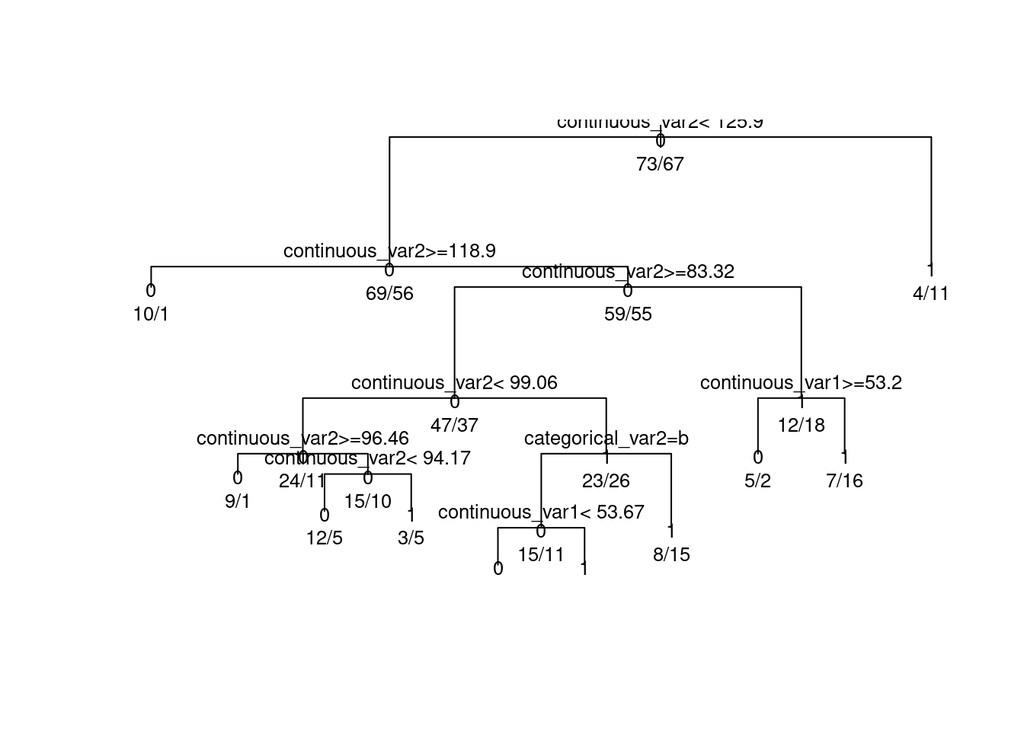

```r
# Plot the decision tree
plot(decision_tree_model)
text(decision_tree_model, use.n = TRUE, all = TRUE, cex = 0.8)
```

# d. Predict the released variable in the test datasets using both model and interpret the results

```r
# Predict using logistic regression model
logistic_predictions <- predict(logistic_model, newdata = test_data, type = "response")
# Convert probabilities to binary predictions
logistic_predictions_binary <- ifelse(logistic_predictions > 0.5, 1, 0)
# Predict using decision tree model
decision_tree_predictions <- predict(decision_tree_model, newdata = test_data, type = "class")
# Create a confusion matrix for logistic regression predictions
logistic_confusion_matrix <- table(test_data$binary_var, logistic_predictions_binary)
print(logistic_confusion_matrix)
```

```
##    logistic_predictions_binary
##      0  1
##   0 20 12
##   1 15 13
```

```r
# use caret package to calculate accuracy
library(caret)
logistic_accuracy_caret <- confusionMatrix(as.factor(logistic_predictions_binary), as.factor(test_data$binary_var))
print(logistic_accuracy_caret)
```

```
## Confusion Matrix and Statistics
##
##           Reference
## Prediction  0  1
##          0 20 15
##          1 12 13
##
##                Accuracy : 0.55
##                  95% CI : (0.4161, 0.6788)
##     No Information Rate : 0.5333
##     P-Value [Acc > NIR] : 0.4497
##
##                   Kappa : 0.0899
##
##  Mcnemar's Test P-Value : 0.7003
##
##             Sensitivity : 0.6250
##             Specificity : 0.4643
##          Pos Pred Value : 0.5714
##          Neg Pred Value : 0.5200
##              Prevalence : 0.5333
##          Detection Rate : 0.3333
##    Detection Prevalence : 0.5833
##       Balanced Accuracy : 0.5446
##
##        'Positive' Class : 0
##
```

```r
decision_tree_accuracy_caret <- confusionMatrix(as.factor(decision_tree_predictions), as.factor(test_data$binary_var))
print(decision_tree_accuracy_caret)
```

```
## Confusion Matrix and Statistics
##
##           Reference
## Prediction  0  1
##          0 13 12
##          1 19 16
##
##                Accuracy : 0.4833
##                  95% CI : (0.3523, 0.6161)
##     No Information Rate : 0.5333
##     P-Value [Acc > NIR] : 0.8175
##
##                   Kappa : -0.022
##
##  Mcnemar's Test P-Value : 0.2812
##
##             Sensitivity : 0.4062
##             Specificity : 0.5714
##          Pos Pred Value : 0.5200
##          Neg Pred Value : 0.4571
##              Prevalence : 0.5333
##          Detection Rate : 0.2167
##    Detection Prevalence : 0.4167
##       Balanced Accuracy : 0.4888
##
##        'Positive' Class : 0
##
```

## Interpretation

The logistic regression model achieved an `accuracy of 0.55 ie. 55% with 95% CI : (0.4161, 0.6788)`, while the decision tree model achieved an `accuracy of 0.48 i.e 48% with 95% CI : (0.3523, 0.6161)` on the test dataset.

The specificity and sensitivity for the logistic regression model were 0.46 and 0.62, respectively, while for the decision tree model, they were 0.57 and 0.40, respectively.

Thus oberving the accuracy and other metrics, we can conclude that the logistic regression model performed better than the decision tree model in this case.